# Analisis Klaster dengan K-Means

Oleh : Fayadh Abiyyi

## 1. Load library yang dibutuhkan

```r
library(dplyr) # library untuk manipulasi data
library(cluster) # library untuk analisis klaster
library(NbClust) # library untuk analisis klaster
library(factoextra) # library analisis klaster dan visualisasi klaster
library(reshape2) # manipulasi data
library(rio)
```

## 2. Load data & Sedikit EDA

```r
terstruktur_11 <- rio::import("https://raw.githubusercontent.com/fayadh-abi/stis/main/dataset/crime.csv")
str(terstruktur_11) # tampilkan struktur data crime
```

```
## 'data.frame':    51 obs. of  9 variables:
##  $ City    : chr  "AK" "AL" "AR" "AZ" ...
##  $ Murder  : num  8.6 10.1 8.1 9.3 11.3 7 4.6 31 4.9 11.7 ...
##  $ Rape    : num  72.7 28.4 28.9 43 44.9 42.3 23.8 52.4 56.9 52.7 ...
##  $ Robbery : int  88 112 80 169 343 145 192 754 124 367 ...
##  $ Assault : int  401 408 278 437 521 329 205 668 241 605 ...
##  $ Burglary: int  1162 1159 1030 1908 1696 1792 1198 1728 1042 2221 ...
##  $ Theft   : int  3910 2304 2305 4337 3384 4231 2758 4131 3090 4373 ...
##  $ Vehicle : int  604 267 195 419 762 486 447 975 272 598 ...
##  $ Type    : int  2 2 1 2 2 2 1 2 1 2 ...
```

```r
terstruktur_11 <- terstruktur_11 %>% select(-c(Type)) # keluarkan variabel type
head(terstruktur_11,6) # tampilkan 6 data pertama dari data
```

```
##   City Murder Rape Robbery Assault Burglary Theft Vehicle
## 1   AK    8.6 72.7      88     401     1162  3910     604
## 2   AL   10.1 28.4     112     408     1159  2304     267
## 3   AR    8.1 28.9      80     278     1030  2305     195
## 4   AZ    9.3 43.0     169     437     1908  4337     419
## 5   CA   11.3 44.9     343     521     1696  3384     762
## 6   CO    7.0 42.3     145     329     1792  4231     486
```

```r
data_boxplot <- melt(terstruktur_11[,-1]) #konversi data menjadi long format
head(data_boxplot,6) # tampilkan 6 data pertama dalam long format
```

```
##   variable value
## 1   Murder   8.6
## 2   Murder  10.1
## 3   Murder   8.1
## 4   Murder   9.3
## 5   Murder  11.3
## 6   Murder   7.0
```

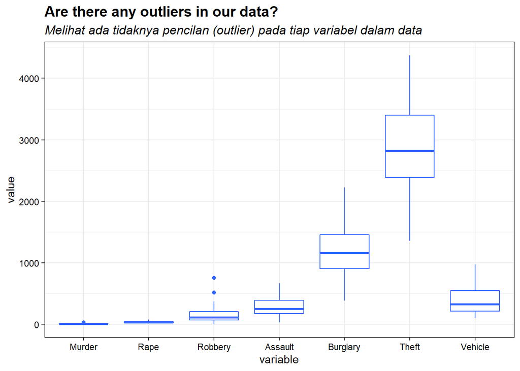

```r
data_boxplot %>% ggplot(aes(x=variable,y=value)) + geom_boxplot(fill = "white", colour = "#3366FF") +
   custom_theme +  labs(title = "Are there any outliers in our data?",
         subtitle = "Melihat ada tidaknya pencilan (outlier) pada tiap variabel dalam data")
```

> **Variabel dalam dataset :**  
> 1. Murder : pembunuhan  
> 2. Rape : pemerkosaan  
> 3. Robbery : perampokan  
> 4. Assault : penyerangan  
> 5. Burglary : perampokan  
> 6. Theft : pencurian  
> 7. Vehicles : pencurian kendaraan bermotor

> **Disclaimer :**  
> Pada identifikasi diatas terlihat bahwa terdapat pencilan pada variabel murder dan robbery. Namun, pada analisis ini tetap digunakan k-means sebagai algoritma untuk melakukan klasterisasi walaupun pada dasarnya algoritma ini tidak robust terhadap adanya pencilan. Sebagai alternatif bagi pembaca, dapat pula digunakan metode PAM atau K-medoids yang lebih robust terhadap adanya pencilan.

## 3. Analisis Klaster

### 3.1. K-Means Clustering

> - **Standarisasi data**  
>   Untuk menghindari kesalahan akibat satuan yang berbeda antar variabel dalam data, maka penulis melakukan standarisasi normal baku.

```r
data.fix <- terstruktur_11 %>% select(-City) %>% scale() # buat dataframe dg var. yang distandarisasi
head(data.fix,6) # tampilkan 6 data pertama
```

```
##        Murder       Rape     Robbery     Assault   Burglary      Theft    Vehicle
## 1  0.28006198  2.6410344 -0.47960926  0.79309857 -0.1068723  1.2680267  0.9397808
## 2  0.59146811 -0.3992637 -0.30546457  0.84028794 -0.1139847 -0.8356596 -0.5672179
## 3  0.17625994 -0.3649488 -0.53765749 -0.03608599 -0.4198189 -0.8343497 -0.8891880
## 4  0.42538484  0.6027307  0.10812905  1.03578673  1.6617504  1.8273505  0.1124966
## 5  0.84059301  0.7331273  1.37067802  1.60205912  1.1591391  0.5790236  1.6463261
## 6 -0.05210455  0.5546899 -0.06601563  0.30772225  1.3867367  1.6885020  0.4121076
```

> - **Menentukan jumlah klaster (k) yang optimal**  
>   Penentuan jumlah klaster dilakukan dengan metode Elbow, Silhouette, Gap statistic dan 30 indikator.
> - **a.) Elbow**

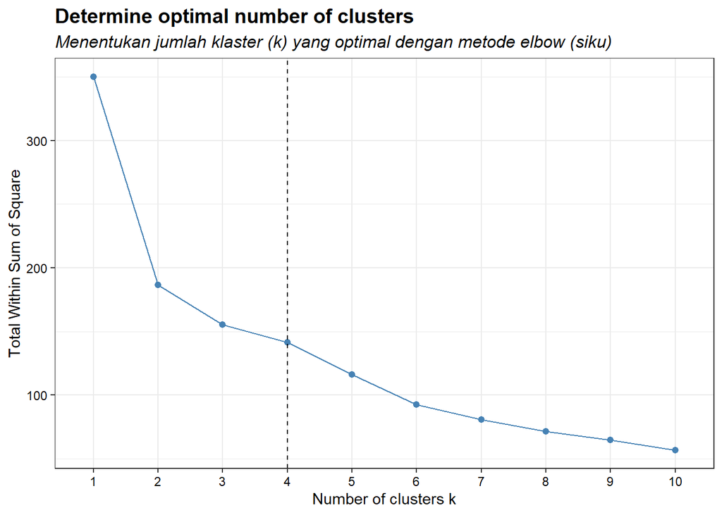

```r
fviz_nbclust(data.fix, kmeans, method = "wss") + # Menggunakan Elbow Method
geom_vline(xintercept = 4, linetype = 2) + custom_theme +
    labs(title = "Determine optimal number of clusters",
         subtitle = "Menentukan jumlah klaster (k) yang optimal dengan metode elbow (siku)")
```

> - **b.) Silhouette**

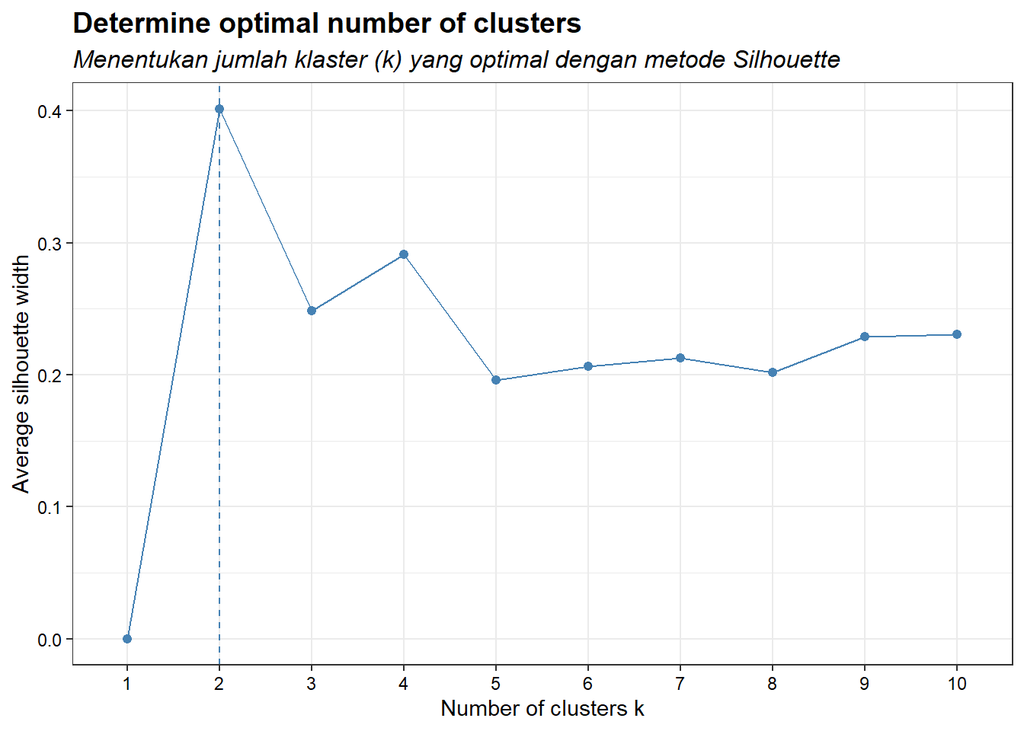

```r
fviz_nbclust(data.fix, kmeans, method = "silhouette")+
custom_theme +
    labs(title = "Determine optimal number of clusters",
         subtitle = "Menentukan jumlah klaster (k) yang optimal dengan metode Silhouette")
```

> - **c.) Gap Statistic**

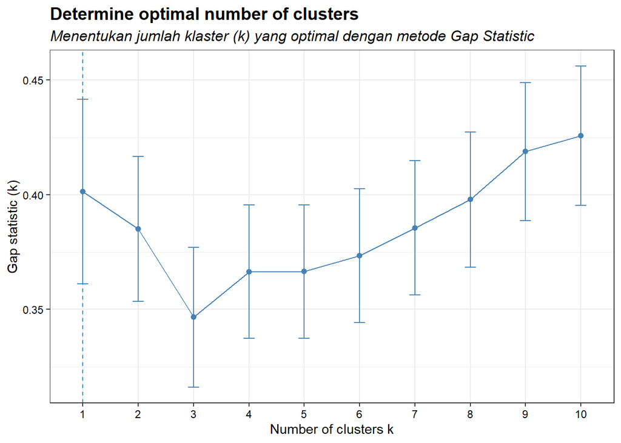

```r
set.seed(123)
fviz_nbclust(data.fix, kmeans, nstart = 25, method = "gap_stat", nboot = 500)+
custom_theme +
    labs(title = "Determine optimal number of clusters",
         subtitle = "Menentukan jumlah klaster (k) yang optimal dengan metode Gap Statistic")
```

> - **d.) 30 Indicators**

```
## Among all indices:
## ===================
## * 2 proposed  0 as the best number of clusters
## * 1 proposed  1 as the best number of clusters
## * 8 proposed  2 as the best number of clusters
## * 2 proposed  3 as the best number of clusters
## * 7 proposed  4 as the best number of clusters
## * 1 proposed  5 as the best number of clusters
## * 1 proposed  6 as the best number of clusters
## * 4 proposed  10 as the best number of clusters
##
## Conclusion
## =========================
## * According to the majority rule, the best number of clusters is  2 .
```

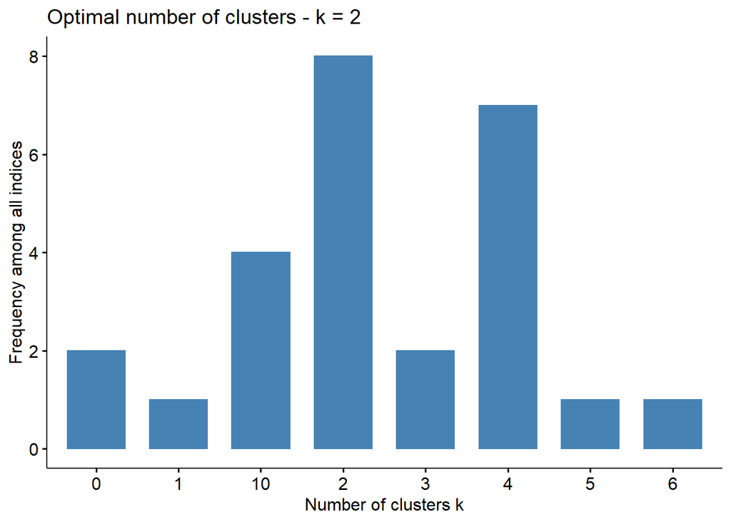

```r
# nb <- NbClust(data.fix, distance = "euclidean", min.nc = 2, max.nc = 10, method = "kmeans")
fviz_nbclust(nb)
```

```r
set.seed(123) # agar mendapatkan hasil yang sama
km.res <- eclust(data.fix,FUNcluster = "kmeans",k=2,nstart=25,graph = F) # jalankan k-means
hasil.klaster <- cbind(terstruktur_11,Cluster=km.res$cluster) # Gabungan hasil klasterisasi dengan data awal
hasil.klaster
```

```
##    City Murder Rape Robbery Assault Burglary Theft Vehicle Cluster
## 1    AK    8.6 72.7      88     401     1162  3910     604       2
## 2    AL   10.1 28.4     112     408     1159  2304     267       1
## 3    AR    8.1 28.9      80     278     1030  2305     195       1
## 4    AZ    9.3 43.0     169     437     1908  4337     419       2
## 5    CA   11.3 44.9     343     521     1696  3384     762       2
## 6    CO    7.0 42.3     145     329     1792  4231     486       2
## 7    CT    4.6 23.8     192     205     1198  2758     447       1
## 8    DC   31.0 52.4     754     668     1728  4131     975       2
## 9    DE    4.9 56.9     124     241     1042  3090     272       1
## 10   FL   11.7 52.7     367     605     2221  4373     598       2
## 11   GA   11.2 43.9     214     319     1453  2984     430       2
## 12   HI    4.8 31.0     106     103     1339  3759     328       1
## 13   IA    1.8 12.5      42     179      956  2801     158       1
## 14   ID    3.2 20.0      21     178     1003  2800     181       1
```

[output cut: 37 more lines]

> - **Bagaimana karakteristik tiap variabel pada dua klaster yang terbentuk?**  
>   Disini kita bisa melihat karakteristik rata-rata (mean) dari dua klaster yang telah terbentuk.

```r
karakteristik <- terstruktur_11 %>% select(-City) %>% aggregate(by=list(cluster=km.res$cluster), mean)
karakteristik
```

```
##   cluster   Murder     Rape  Robbery Assault  Burglary    Theft  Vehicle
## 1       1  4.85000 25.11333  81.0000   193.3  936.1667 2550.033 275.4000
## 2       2 10.68095 47.22381 258.5238   412.0 1594.0952 3501.857 563.0476
```

> Dari output diatas terlihat bahwa kota pada klaster 1 memiliki nilai rata-rata indikator kejahatan yang relatif rendah. Sebaliknya, klaster 2 terdiri dari kota dengan rata-rata indikator kejahatan yang tinggi atau dengan kata lain tingkat kejahatan pada kota di klaster 2 tergolong cukup masif.
> - **Berapa jumlah kota yang ada pada tiap klaster?**

```r
hasil.klaster$Cluster <- as.factor(hasil.klaster$Cluster)
j.anggota <- hasil.klaster %>% count(Cluster)
j.anggota
```

```
##   Cluster  n
## 1       1 30
## 2       2 21
```

> Output diatas menampilkan jumlah anggota pada tiap klaster. Dari situ terlihat bahwa klaster pertama terdiri dari 30 kota dan klaster kedua terdiri dari 21 kota.
> - **Visualisasi Hasil Klasterisasi**

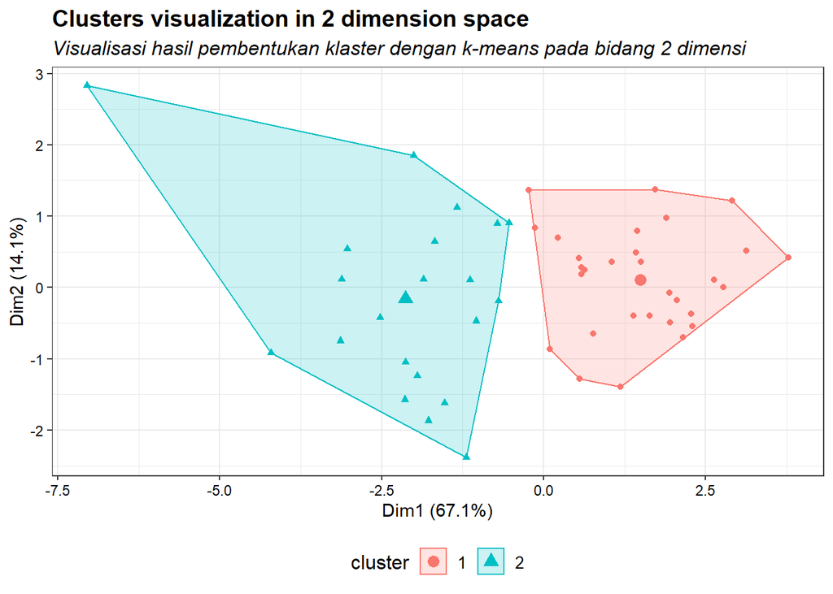

```r
fviz_cluster(km.res, geom = "point", ellips.type = "norm", palatte ="jco",
             ggtheme = theme_minimal()) + custom_theme +
  labs(title = "Clusters visualization in 2 dimension space",
       subtitle = "Visualisasi hasil pembentukan klaster dengan k-means pada bidang 2 dimensi" ) +
  theme(legend.position = "bottom")
```